# Covid Country Analysis

```r
library(ggplot2)
library(hrbrthemes)
library(GGally)
library(corrgram)
library(visdat)
library(ISLR2)
library(e1071)
library(caTools)
library(hopkins)
#library(randomForest)
```

Context

- A new coronavirus designated 2019-nCoV was first identified in Wuhan, the capital of China's Hubei province
- People developed pneumonia without a clear cause and for which existing vaccines or treatments were not effective.
- The virus has shown evidence of human-to-human transmission
- Transmission rate (rate of infection) appeared to escalate in mid-January 2020
- As of 30 January 2020, approximately 8,243 cases have been confirmed
- full_grouped.csv - Day to day country wise no. of cases (Has County/State/Province level data)
- covid19clean_complete.csv - Day to day country wise no. of cases (Doesn't have County/State/Province level data)
- countrywiselatest.csv - Latest country level no. of cases
- day_wise.csv - Day wise no. of cases (Doesn't have country level data)
- usacountywise.csv - Day to day county level no. of cases
- worldometer_data.csv - Latest data from https://www.worldometers.info/

```r
# Import datasets from csv

# Source: https://www.kaggle.com/datasets/imdevskp/corona-virus-report?resource=download&select=country_wise_latest.csv

# Online from github repo
df = read.csv('https://raw.githubusercontent.com/Giovo17/covid-country-analysis/main/country_wise_latest.csv')

# Local from disk
#df = read.csv("country_wise_latest.csv")
```

```r
head(df, 7)
str(df)
summary(df)
```

A data.frame: 7 × 15

|  | Country.Region <chr> | Confirmed <int> | Deaths <int> | Recovered <int> | Active <int> | New.cases <int> | New.deaths <int> | New.recovered <int> | Deaths...100.Cases <dbl> | Recovered...100.Cases <dbl> | Deaths...100.Recovered <dbl> | Confirmed.last.week <int> | X1.week.change <int> | X1.week...increase <dbl> | WHO.Region <chr> |
| --- | --- | --- | --- | --- | --- | --- | --- | --- | --- | --- | --- | --- | --- | --- | --- |
| 1 | Afghanistan | 36263 | 1269 | 25198 | 9796 | 106 | 10 | 18 | 3.50 | 69.49 | 5.04 | 35526 | 737 | 2.07 | Eastern Mediterranean |
| 2 | Albania | 4880 | 144 | 2745 | 1991 | 117 | 6 | 63 | 2.95 | 56.25 | 5.25 | 4171 | 709 | 17.00 | Europe |
| 3 | Algeria | 27973 | 1163 | 18837 | 7973 | 616 | 8 | 749 | 4.16 | 67.34 | 6.17 | 23691 | 4282 | 18.07 | Africa |
| 4 | Andorra | 907 | 52 | 803 | 52 | 10 | 0 | 0 | 5.73 | 88.53 | 6.48 | 884 | 23 | 2.60 | Europe |
| 5 | Angola | 950 | 41 | 242 | 667 | 18 | 1 | 0 | 4.32 | 25.47 | 16.94 | 749 | 201 | 26.84 | Africa |
| 6 | Antigua and Barbuda | 86 | 3 | 65 | 18 | 4 | 0 | 5 | 3.49 | 75.58 | 4.62 | 76 | 10 | 13.16 | Americas |
| 7 | Argentina | 167416 | 3059 | 72575 | 91782 | 4890 | 120 | 2057 | 1.83 | 43.35 | 4.21 | 130774 | 36642 | 28.02 | Americas |

```
'data.frame':	187 obs. of  15 variables:
 $ Country.Region        : chr  "Afghanistan" "Albania" "Algeria" "Andorra" ...
 $ Confirmed             : int  36263 4880 27973 907 950 86 167416 37390 15303 20558 ...
 $ Deaths                : int  1269 144 1163 52 41 3 3059 711 167 713 ...
 $ Recovered             : int  25198 2745 18837 803 242 65 72575 26665 9311 18246 ...
 $ Active                : int  9796 1991 7973 52 667 18 91782 10014 5825 1599 ...
 $ New.cases             : int  106 117 616 10 18 4 4890 73 368 86 ...
 $ New.deaths            : int  10 6 8 0 1 0 120 6 6 1 ...
 $ New.recovered         : int  18 63 749 0 0 5 2057 187 137 37 ...
 $ Deaths...100.Cases    : num  3.5 2.95 4.16 5.73 4.32 3.49 1.83 1.9 1.09 3.47 ...
 $ Recovered...100.Cases : num  69.5 56.2 67.3 88.5 25.5 ...
 $ Deaths...100.Recovered: num  5.04 5.25 6.17 6.48 16.94 ...
 $ Confirmed.last.week   : int  35526 4171 23691 884 749 76 130774 34981 12428 19743 ...
 $ X1.week.change        : int  737 709 4282 23 201 10 36642 2409 2875 815 ...
 $ X1.week...increase    : num  2.07 17 18.07 2.6 26.84 ...
 $ WHO.Region            : chr  "Eastern Mediterranean" "Europe" "Africa" "Europe" ...
```

```
 Country.Region       Confirmed           Deaths           Recovered
 Length:187         Min.   :     10   Min.   :     0.0   Min.   :      0.0
 Class :character   1st Qu.:   1114   1st Qu.:    18.5   1st Qu.:    626.5
 Mode  :character   Median :   5059   Median :   108.0   Median :   2815.0
                    Mean   :  88131   Mean   :  3497.5   Mean   :  50631.5
                    3rd Qu.:  40460   3rd Qu.:   734.0   3rd Qu.:  22606.0
                    Max.   :4290259   Max.   :148011.0   Max.   :1846641.0
     Active            New.cases         New.deaths      New.recovered
 Min.   :      0.0   Min.   :    0.0   Min.   :   0.00   Min.   :    0.0
 1st Qu.:    141.5   1st Qu.:    4.0   1st Qu.:   0.00   1st Qu.:    0.0
 Median :   1600.0   Median :   49.0   Median :   1.00   Median :   22.0
 Mean   :  34001.9   Mean   : 1223.0   Mean   :  28.96   Mean   :  933.8
 3rd Qu.:   9149.0   3rd Qu.:  419.5   3rd Qu.:   6.00   3rd Qu.:  221.0
 Max.   :2816444.0   Max.   :56336.0   Max.   :1076.00   Max.   :33728.0
 Deaths...100.Cases Recovered...100.Cases Deaths...100.Recovered
 Min.   : 0.000     Min.   :  0.00        Min.   :0.00
 1st Qu.: 0.945     1st Qu.: 48.77        1st Qu.:1.45
 Median : 2.150     Median : 71.32        Median :3.62
 Mean   : 3.020     Mean   : 64.82        Mean   : Inf
 3rd Qu.: 3.875     3rd Qu.: 86.89        3rd Qu.:6.44
 Max.   :28.560     Max.   :100.00        Max.   : Inf
 Confirmed.last.week X1.week.change   X1.week...increase  WHO.Region
 Min.   :     10     Min.   :   -47   Min.   : -3.840    Length:187
 1st Qu.:   1052     1st Qu.:    49   1st Qu.:  2.775    Class :character
 Median :   5020     Median :   432   Median :  6.890    Mode  :character
 Mean   :  78682     Mean   :  9448   Mean   : 13.606
 3rd Qu.:  37080     3rd Qu.:  3172   3rd Qu.: 16.855
 Max.   :3834677     Max.   :455582   Max.   :226.320
```

- Are there any missing data?

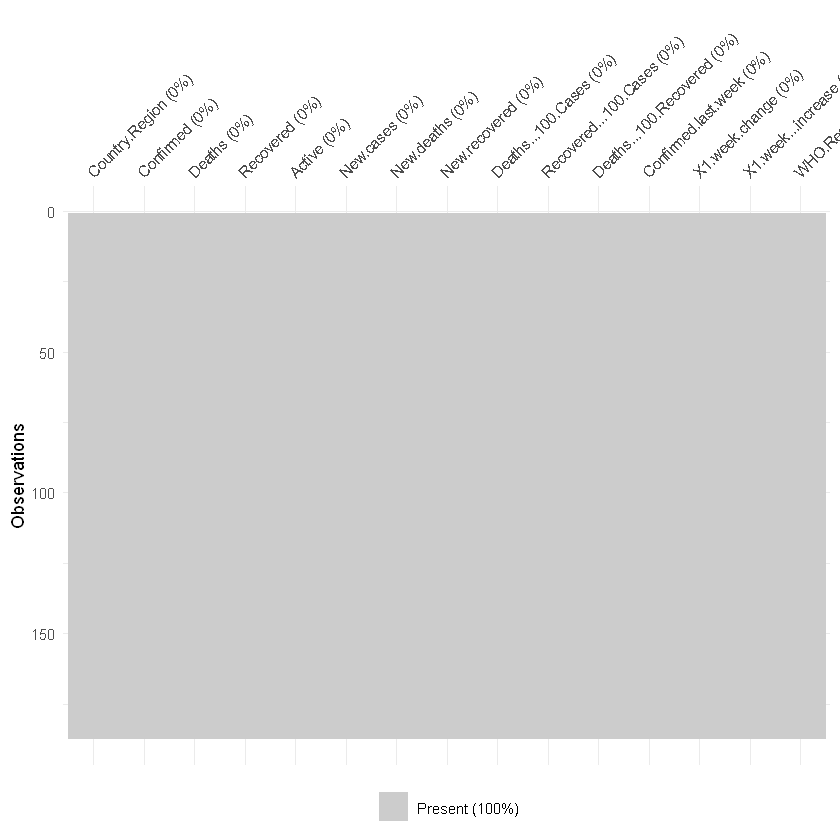

```r
vis_miss(df)
```

```r
# Removed a row with a strange value
df = df[!(df$Deaths...100.Recovered=="Inf" ),]
```

- How each variable is distributed?
- Are there any strange behaviour?

Let's explore the dataset

## EDA

```r
print(colnames(df))
```

```
 [1] "Country.Region"         "Confirmed"              "Deaths"
 [4] "Recovered"              "Active"                 "New.cases"
 [7] "New.deaths"             "New.recovered"          "Deaths...100.Cases"
[10] "Recovered...100.Cases"  "Deaths...100.Recovered" "Confirmed.last.week"
[13] "X1.week.change"         "X1.week...increase"     "WHO.Region"
```

### Univariate EDA

#### Confirmed

```r
boxplot.stats(df$Confirmed)
```

**$stats**

1. 10

2. 1100

3. 4970

4. 39741

5. 92482

**$n**

182

**$conf**

1. 444.466854473945

2. 9495.53314552605

**$out**

1. 167416

2. 226225

3. 2442375

4. 347923

5. 257101

6. 220352

7. 207112

8. 1480073

9. 100303

10. 293606

11. 112585

12. 246286

13. 395489

14. 274289

15. 389717

16. 109597

17. 816680

18. 268934

19. 452529

20. 272421

21. 227019

22. 4290259

23. 301708

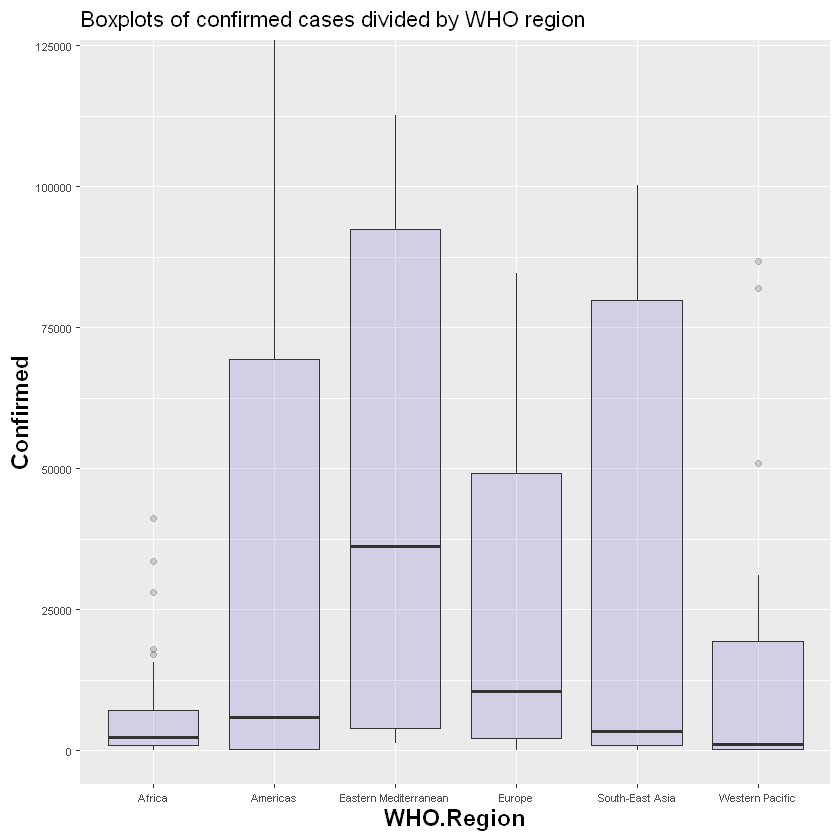

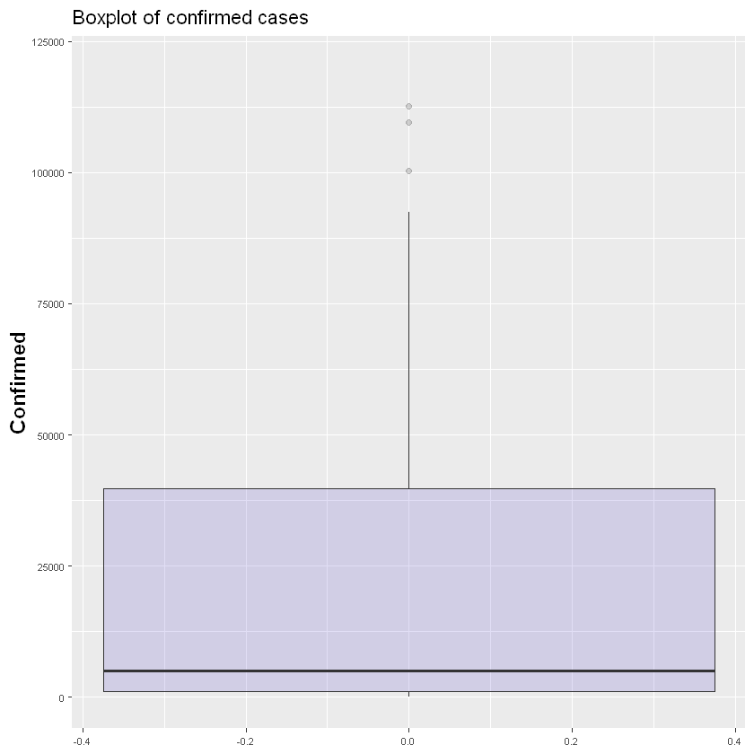

```r
ggplot(df, aes(x=as.factor(WHO.Region), y=Confirmed)) +
    geom_boxplot(fill="slateblue", alpha=0.2) +
    ggtitle("Boxplots of confirmed cases divided by WHO region") +
    theme(
        axis.text=element_text(size=6.5),
        axis.title=element_text(size=14, face="bold")
    ) +
    coord_cartesian(ylim = c(0, 120000)) +
    xlab("WHO.Region")

ggplot(df, aes(y=Confirmed)) +
    geom_boxplot(fill="slateblue", alpha=0.2) +
    ggtitle("Boxplot of confirmed cases") +
    theme(
        axis.text=element_text(size=6.5),
        axis.title=element_text(size=14, face="bold")
    ) +
    coord_cartesian(ylim = c(0, 120000))
```

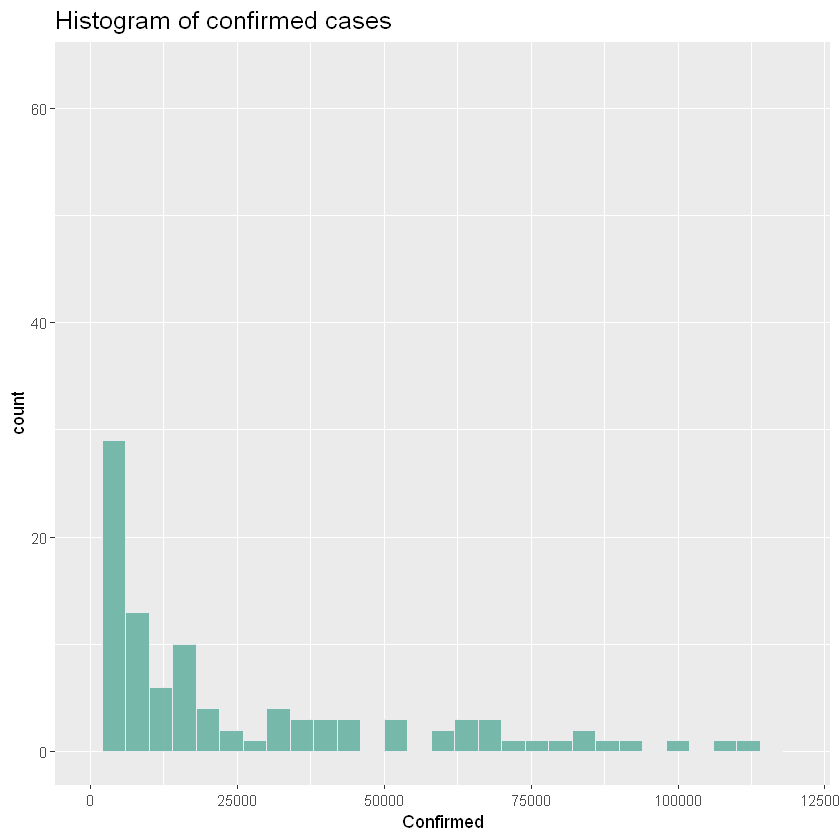

```r
ggplot(df, aes(x=Confirmed)) +
    geom_histogram( binwidth=4000, fill="#69b3a2", color="#e9ecef", alpha=0.9, position = 'identity') +
    ggtitle("Histogram of confirmed cases") +
    theme(plot.title = element_text(size=15)) +
    xlim(0,120000)
```

```r
png(filename = "img/Confirmed_conditional_boxplot.png", units="in", width=5, height=5, res=300)

ggplot(df, aes(x=as.factor(WHO.Region), y=Confirmed)) +
    geom_boxplot(fill="slateblue", alpha=0.2) +
    ggtitle("Boxplots of confirmed cases divided by WHO region") +
    theme(
        axis.text=element_text(size=6.5),
        axis.title=element_text(size=14,face="bold")
    ) +
    coord_cartesian(ylim = c(0, 120000)) +
    xlab("WHO.Region")

dev.off()

png(filename = "img/Confirmed_boxplot.png", units="in", width=5, height=5, res=300)

ggplot(df, aes(y=Confirmed)) +
    geom_boxplot(fill="slateblue", alpha=0.2) +
    ggtitle("Boxplot of confirmed cases") +
    theme(
        axis.text=element_text(size=6.5),
        axis.title=element_text(size=14, face="bold")
    ) +
    coord_cartesian(ylim = c(0, 120000))

dev.off()

png(filename = "img/Confirmed_histogram.png", units="in", width=5, height=5, res=300)

ggplot(df, aes(Confirmed)) +
    geom_histogram( binwidth=4000, fill="#69b3a2", color="#e9ecef", alpha=0.9) +
    ggtitle("Histogram of confirmed cases") +
    theme(plot.title = element_text(size=15)) +
    xlim(0,120000)

dev.off()
```

**png:** 2

**png:** 2

**png:** 2

#### Deaths

```r
boxplot.stats(df$Deaths)
```

**$stats**

1. 0

2. 18

3. 103.5

4. 720

5. 1764

**$n**

182

**$conf**

1. 21.2835907932173

2. 185.716409206783

**$out**

1. 3059

2. 2965

3. 9822

4. 2647

5. 87618

6. 9187

7. 4656

8. 8777

9. 5532

10. 4652

11. 30212

12. 9125

13. 33408

14. 4838

15. 15912

16. 4458

17. 35112

18. 44022

19. 6160

20. 5842

21. 18418

22. 1945

23. 2206

24. 13334

25. 2760

26. 7067

27. 28432

28. 1978

29. 5630

30. 148011

31. 45844

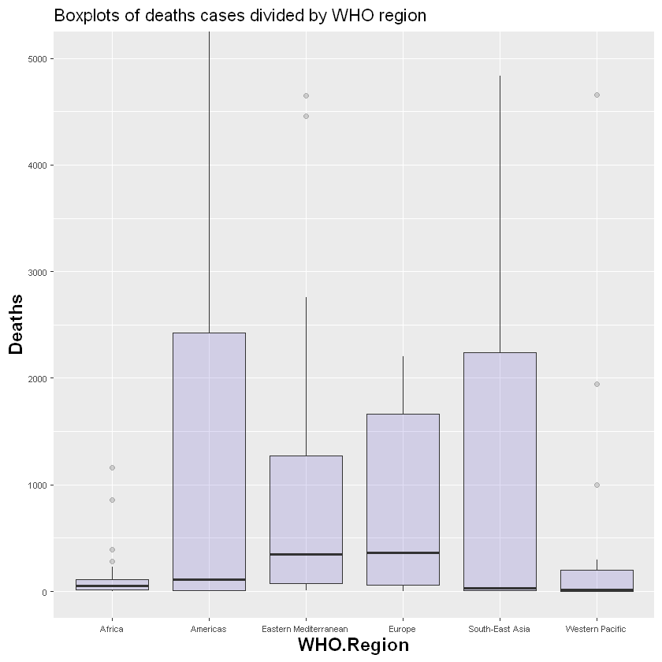

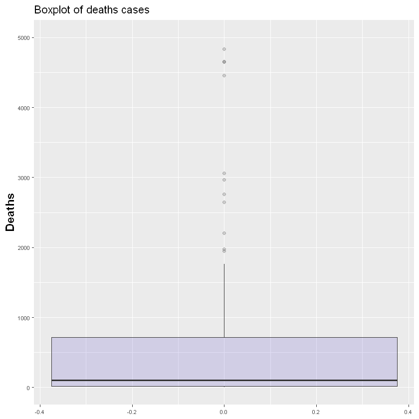

```r
ggplot(df, aes(x=as.factor(WHO.Region), y=Deaths)) +
    geom_boxplot(fill="slateblue", alpha=0.2) +
    ggtitle("Boxplots of deaths cases divided by WHO region") +
    theme(
        axis.text=element_text(size=6.5),
        axis.title=element_text(size=14,face="bold")
    ) +
    coord_cartesian(ylim = c(0, 5000)) +
    xlab("WHO.Region")

ggplot(df, aes(y=Deaths)) +
    geom_boxplot(fill="slateblue", alpha=0.2) +
    ggtitle("Boxplot of deaths cases") +
    theme(
        axis.text=element_text(size=6.5),
        axis.title=element_text(size=14,face="bold")
    ) +
    coord_cartesian(ylim = c(0, 5000))
```

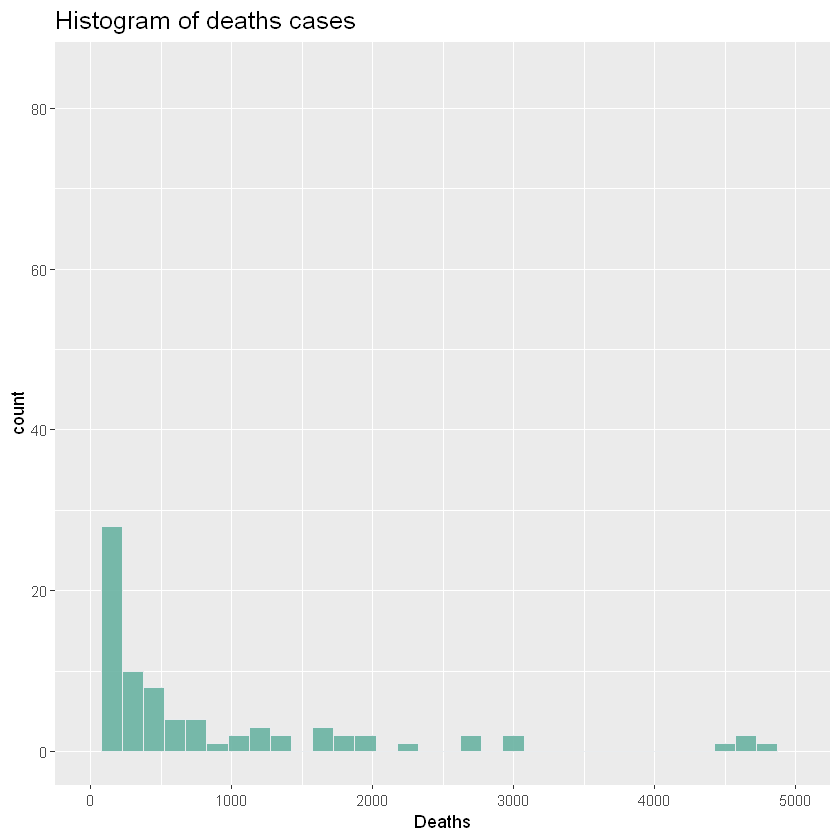

```r
ggplot(df, aes(Deaths)) +
    geom_histogram( binwidth=150, fill="#69b3a2", color="#e9ecef", alpha=0.9) +
    ggtitle("Histogram of deaths cases") +
    theme(plot.title = element_text(size=15)) +
    xlim(0,5000)
```

```r
png(filename = "img/Deaths_conditional_boxplot.png", units="in", width=5, height=5, res=300)

ggplot(df, aes(x=as.factor(WHO.Region), y=Deaths)) +
    geom_boxplot(fill="slateblue", alpha=0.2) +
    ggtitle("Boxplots of deaths cases divided by WHO region") +
    theme(
        axis.text=element_text(size=6.5),
        axis.title=element_text(size=14,face="bold")
    ) +
    coord_cartesian(ylim = c(0, 5000)) +
    xlab("WHO.Region")

dev.off()

png(filename = "img/Deaths_boxplot.png", units="in", width=5, height=5, res=300)

ggplot(df, aes(y=Deaths)) +
    geom_boxplot(fill="slateblue", alpha=0.2) +
    ggtitle("Boxplot of deaths cases") +
    theme(
        axis.text=element_text(size=6.5),
        axis.title=element_text(size=14, face="bold")
    ) +
    coord_cartesian(ylim = c(0, 5000))

dev.off()

png(filename = "img/Deaths_histogram.png", units="in", width=5, height=5, res=300)

ggplot(df, aes(Deaths)) +
    geom_histogram( binwidth=150, fill="#69b3a2", color="#e9ecef", alpha=0.9) +
    ggtitle("Histogram of deaths cases") +
    theme(plot.title = element_text(size=15)) +
    xlim(0,5000)

dev.off()
```

**png:** 2

**png:** 2

**png:** 2

#### Recovered

```r
boxplot.stats(df$Recovered)
```

**$stats**

1. 0

2. 714

3. 3220

4. 23364

5. 57028

**$n**

182

**$conf**

1. 567.291070464917

2. 5872.70892953508

**$out**

1. 72575

2. 125683

3. 60492

4. 1846641

5. 319954

6. 78869

7. 131161

8. 81212

9. 190314

10. 951166

11. 58173

12. 255144

13. 77144

14. 198593

15. 303810

16. 241026

17. 272547

18. 106328

19. 602249

20. 222936

21. 274925

22. 150376

23. 210469

24. 1325804

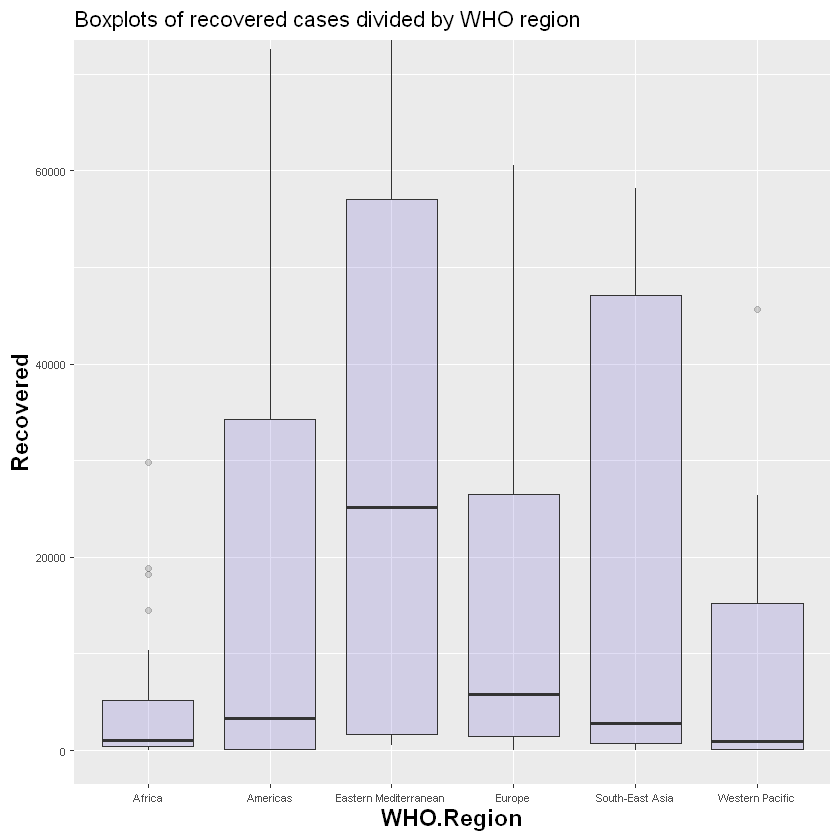

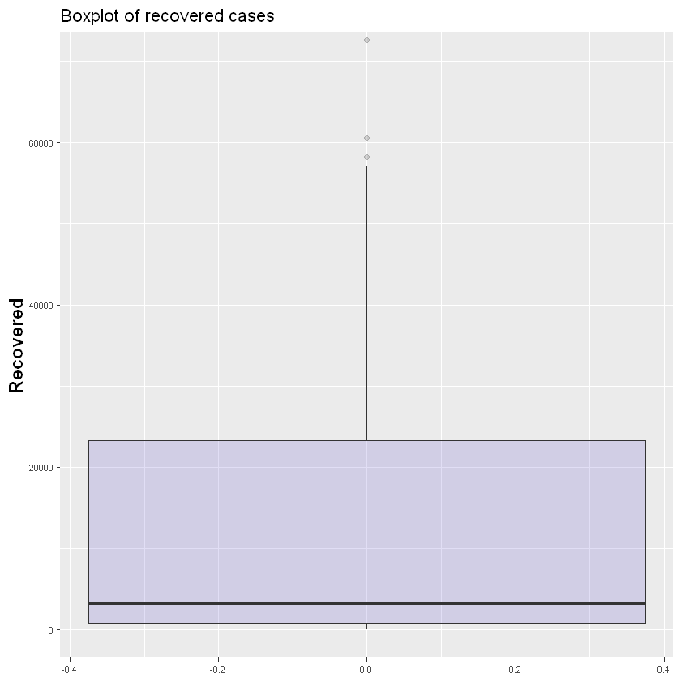

```r
ggplot(df, aes(x=as.factor(WHO.Region), y=Recovered)) +
    geom_boxplot(fill="slateblue", alpha=0.2) +
    ggtitle("Boxplots of recovered cases divided by WHO region") +
    theme(
        axis.text=element_text(size=6.5),
        axis.title=element_text(size=14, face="bold")
    ) +
    coord_cartesian(ylim = c(0, 70000)) +
    xlab("WHO.Region")

ggplot(df, aes(y=Recovered)) +
    geom_boxplot(fill="slateblue", alpha=0.2) +
    ggtitle("Boxplot of recovered cases") +
    theme(
        axis.text=element_text(size=6.5),
        axis.title=element_text(size=14, face="bold")
    ) +
    coord_cartesian(ylim = c(0, 70000))
```

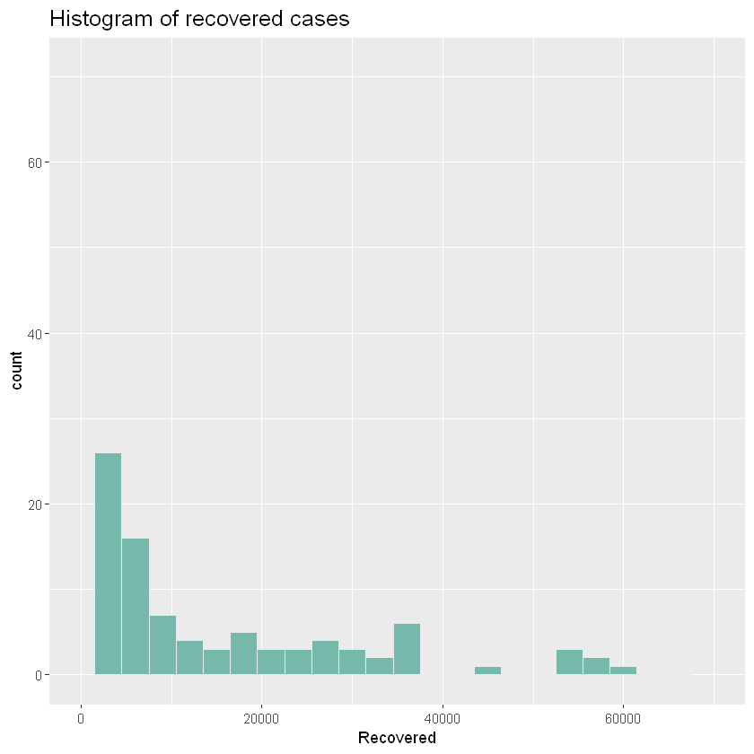

```r
ggplot(df, aes(x=Recovered)) +
    geom_histogram( binwidth=3000, fill="#69b3a2", color="#e9ecef", alpha=0.9, position = 'identity') +
    ggtitle("Histogram of recovered cases") +
    theme(plot.title = element_text(size=15)) +
    xlim(0,70000)
```

```r
png(filename = "img/Recovered_conditional_boxplot.png", units="in", width=5, height=5, res=300)

ggplot(df, aes(x=as.factor(WHO.Region), y=Recovered)) +
    geom_boxplot(fill="slateblue", alpha=0.2) +
    ggtitle("Boxplots of recovered cases divided by WHO region") +
    theme(
        axis.text=element_text(size=6.5),
        axis.title=element_text(size=14,face="bold")
    ) +
    coord_cartesian(ylim = c(0, 70000)) +
    xlab("WHO.Region")

dev.off()

png(filename = "img/Recovered_boxplot.png", units="in", width=5, height=5, res=300)

ggplot(df, aes(y=Recovered)) +
    geom_boxplot(fill="slateblue", alpha=0.2) +
    ggtitle("Boxplot of confirmed cases") +
    theme(
        axis.text=element_text(size=6.5),
        axis.title=element_text(size=14, face="bold")
    ) +
    coord_cartesian(ylim = c(0, 70000))

dev.off()

png(filename = "img/Recovered_histogram.png", units="in", width=5, height=5, res=300)

ggplot(df, aes(Recovered)) +
    geom_histogram( binwidth=3000, fill="#69b3a2", color="#e9ecef", alpha=0.9) +
    ggtitle("Histogram of confirmed cases") +
    theme(plot.title = element_text(size=15)) +
    xlim(0,70000)

dev.off()
```

**png:** 2

**png:** 2

**png:** 2

#### Active

```r
boxplot.stats(df$Active)
```

**$stats**

1. 0

2. 129

3. 1599

4. 8870

5. 19637

**$n**

182

**$conf**

1. 575.27687624432

2. 2622.72312375568

**$out**

1. 91782

2. 97577

3. 39154

4. 47056

5. 508116

6. 117163

7. 32869

8. 40733

9. 52992

10. 108928

11. 33536

12. 495499

13. 37292

14. 22550

15. 30983

16. 36378

17. 29659

18. 47657

19. 47064

20. 22117

21. 27421

22. 25034

23. 98752

24. 53649

25. 201097

26. 43238

27. 170537

28. 93613

29. 2816444

30. 28258

31. 254427

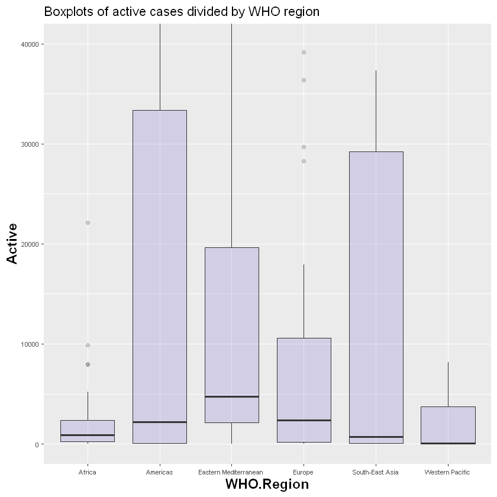

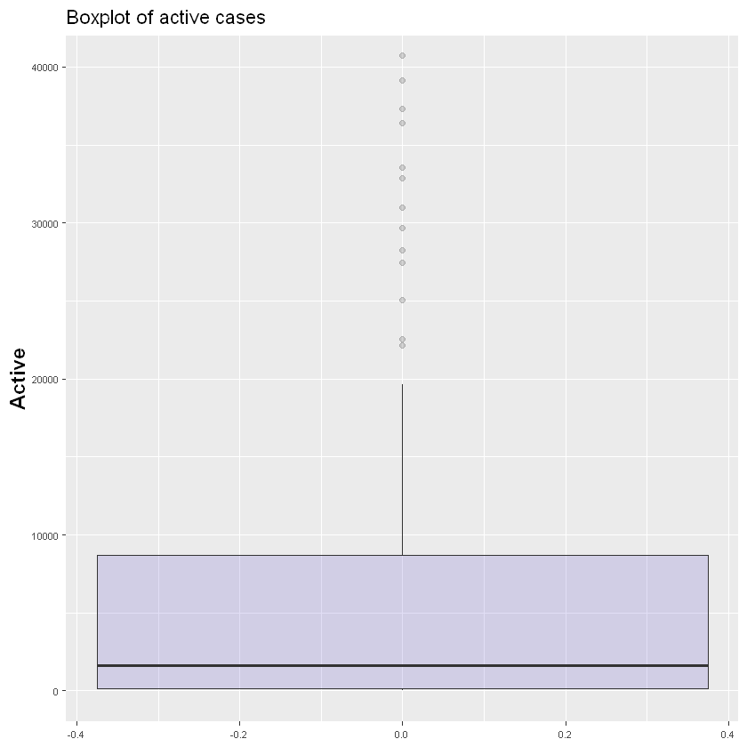

```r
ggplot(df, aes(x=as.factor(WHO.Region), y=Active)) +
    geom_boxplot(fill="slateblue", alpha=0.2) +
    ggtitle("Boxplots of active cases divided by WHO region") +
    theme(
        axis.text=element_text(size=6.5),
        axis.title=element_text(size=14, face="bold")
    ) +
    coord_cartesian(ylim = c(0, 40000)) +
    xlab("WHO.Region")

ggplot(df, aes(y=Active)) +
    geom_boxplot(fill="slateblue", alpha=0.2) +
    ggtitle("Boxplot of active cases") +
    theme(
        axis.text=element_text(size=6.5),
        axis.title=element_text(size=14, face="bold")
    ) +
    coord_cartesian(ylim = c(0, 40000))
```

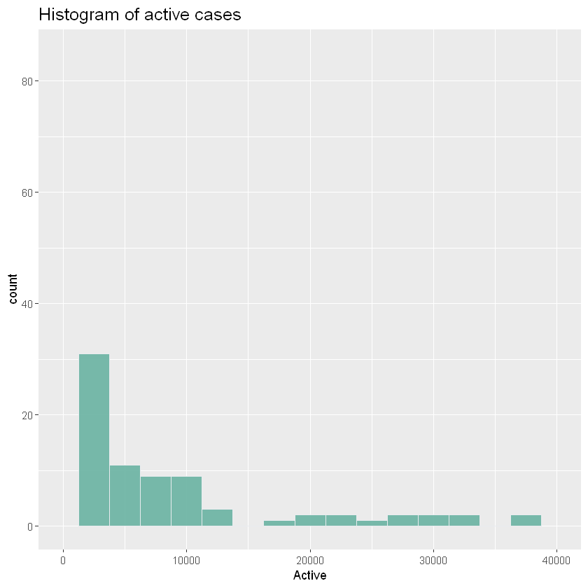

```r
ggplot(df, aes(x=Active)) +
    geom_histogram( binwidth=2500, fill="#69b3a2", color="#e9ecef", alpha=0.9, position = 'identity') +
    ggtitle("Histogram of active cases") +
    theme(plot.title = element_text(size=15)) +
    xlim(0,40000)
```

```r
png(filename = "img/Active_conditional_boxplot.png", units="in", width=5, height=5, res=300)

ggplot(df, aes(x=as.factor(WHO.Region), y=Active)) +
    geom_boxplot(fill="slateblue", alpha=0.2) +
    ggtitle("Boxplots of active cases divided by WHO region") +
    theme(
        axis.text=element_text(size=6.5),
        axis.title=element_text(size=14,face="bold")
    ) +
    coord_cartesian(ylim = c(0, 40000)) +
    xlab("WHO.Region")

dev.off()

png(filename = "img/Active_boxplot.png", units="in", width=5, height=5, res=300)

ggplot(df, aes(y=Active)) +
    geom_boxplot(fill="slateblue", alpha=0.2) +
    ggtitle("Boxplot of active cases") +
    theme(
        axis.text=element_text(size=6.5),
        axis.title=element_text(size=14, face="bold")
    ) +
    coord_cartesian(ylim = c(0, 40000))

dev.off()

png(filename = "img/Active_histogram.png", units="in", width=5, height=5, res=300)

ggplot(df, aes(Active)) +
    geom_histogram( binwidth=2500, fill="#69b3a2", color="#e9ecef", alpha=0.9) +
    ggtitle("Histogram of active cases") +
    theme(plot.title = element_text(size=15)) +
    xlim(0,40000)

dev.off()
```

**png:** 2

**png:** 2

**png:** 2

#### New cases

```r
boxplot.stats(df$New.cases)
```

**$stats**

1. 0

2. 4

3. 49

4. 420

5. 919

**$n**

182

**$conf**

1. 0.279164914499141

2. 97.7208350855009

**$out**

1. 4890

2. 2772

3. 1752

4. 23284

5. 2133

6. 16306

7. 1248

8. 2551

9. 44457

10. 1525

11. 2434

12. 2553

13. 2029

14. 1526

15. 4973

16. 1053

17. 1176

18. 1146

19. 13756

20. 1592

21. 1104

22. 5607

23. 1993

24. 7096

25. 56336

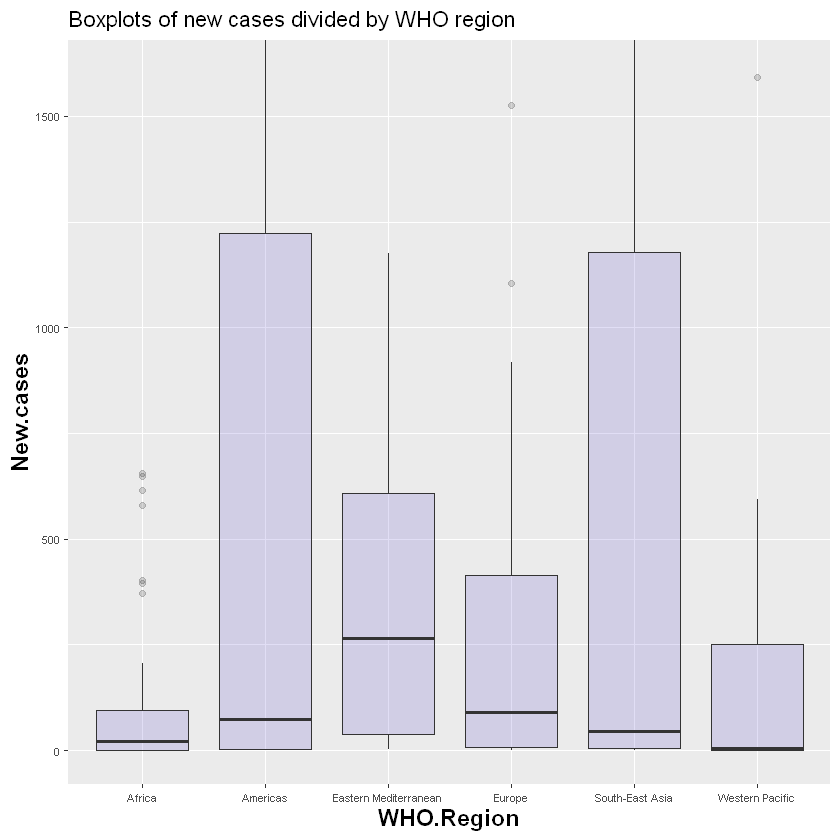

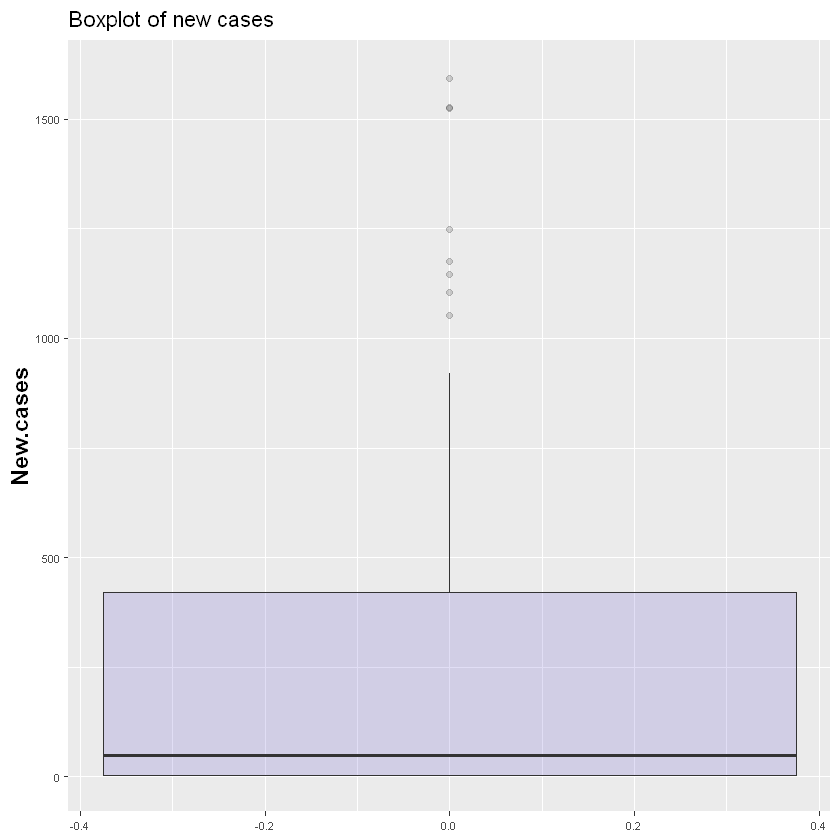

```r
ggplot(df, aes(x=as.factor(WHO.Region), y=New.cases)) +
    geom_boxplot(fill="slateblue", alpha=0.2) +
    ggtitle("Boxplots of new cases divided by WHO region") +
    theme(
        axis.text=element_text(size=6.5),
        axis.title=element_text(size=14, face="bold")
    ) +
    coord_cartesian(ylim = c(0, 1600)) +
    xlab("WHO.Region")

ggplot(df, aes(y=New.cases)) +
    geom_boxplot(fill="slateblue", alpha=0.2) +
    ggtitle("Boxplot of new cases") +
    theme(
        axis.text=element_text(size=6.5),
        axis.title=element_text(size=14, face="bold")
    ) +
    coord_cartesian(ylim = c(0, 1600))
```

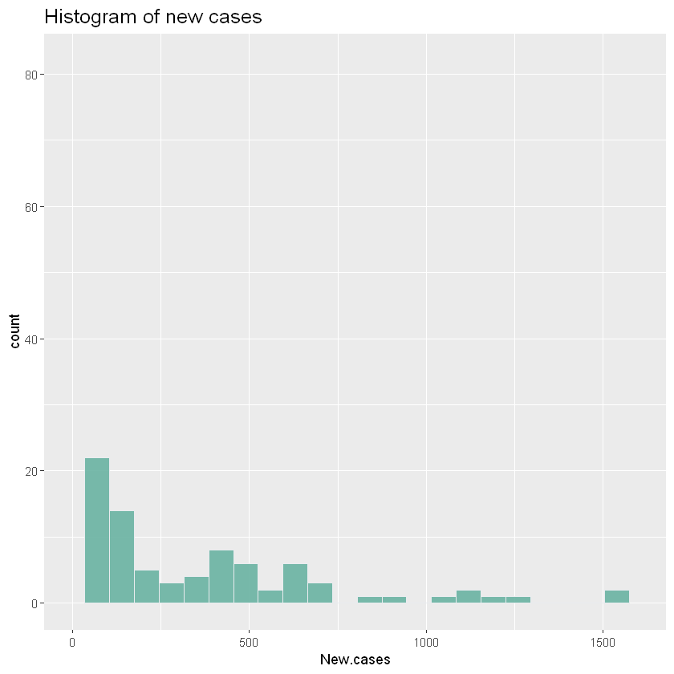

```r
ggplot(df, aes(x=New.cases)) +
    geom_histogram( binwidth=70, fill="#69b3a2", color="#e9ecef", alpha=0.9, position = 'identity') +
    ggtitle("Histogram of new cases") +
    theme(plot.title = element_text(size=15)) +
    xlim(0,1600)
```

```r
png(filename = "img/New_cases_conditional_boxplot.png", units="in", width=5, height=5, res=300)

ggplot(df, aes(x=as.factor(WHO.Region), y=New.cases)) +
    geom_boxplot(fill="slateblue", alpha=0.2) +
    ggtitle("Boxplots of new cases divided by WHO region") +
    theme(
        axis.text=element_text(size=6.5),
        axis.title=element_text(size=14,face="bold")
    ) +
    coord_cartesian(ylim = c(0, 1600)) +
    xlab("WHO.Region")

dev.off()

png(filename = "img/New_cases_boxplot.png", units="in", width=5, height=5, res=300)

ggplot(df, aes(y=New.cases)) +
    geom_boxplot(fill="slateblue", alpha=0.2) +
    ggtitle("Boxplot of new cases") +
    theme(
        axis.text=element_text(size=6.5),
        axis.title=element_text(size=14, face="bold")
    ) +
    coord_cartesian(ylim = c(0, 1600))

dev.off()

png(filename = "img/New_cases_histogram.png", units="in", width=5, height=5, res=300)

ggplot(df, aes(New.cases)) +
    geom_histogram( binwidth=70, fill="#69b3a2", color="#e9ecef", alpha=0.9) +
    ggtitle("Histogram of new cases") +
    theme(plot.title = element_text(size=15)) +
    xlim(0,1600)

dev.off()
```

**png:** 2

**png:** 2

**png:** 2

#### New deaths

```r
boxplot.stats(df$New.deaths)
```

**$stats**

1. 0

2. 0

3. 1

4. 6

5. 14

**$n**

182

**$conf**

1. 0.297295647805276

2. 1.70270435219472

**$out**

1. 120

2. 37

3. 64

4. 614

5. 75

6. 508

7. 20

8. 17

9. 46

10. 17

11. 27

12. 50

13. 637

14. 57

15. 212

16. 96

17. 16

18. 24

19. 342

20. 20

21. 28

22. 575

23. 19

24. 85

25. 27

26. 298

27. 17

28. 1076

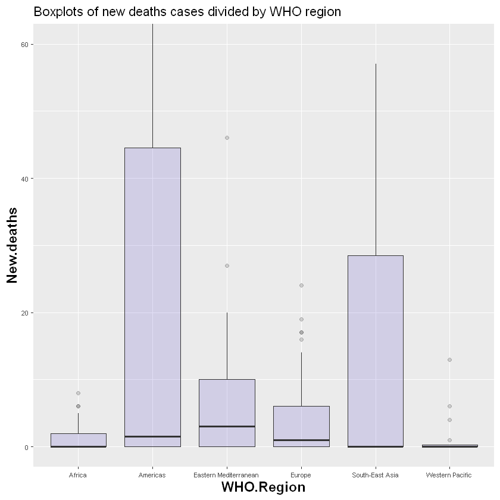

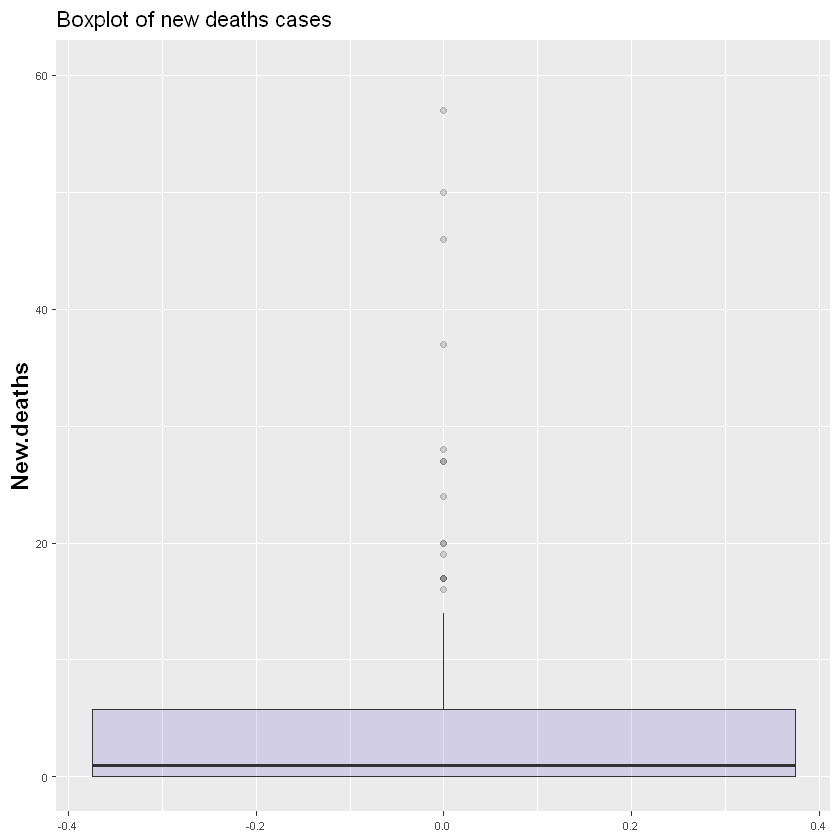

```r
ggplot(df, aes(x=as.factor(WHO.Region), y=New.deaths)) +
    geom_boxplot(fill="slateblue", alpha=0.2) +
    ggtitle("Boxplots of new deaths cases divided by WHO region") +
    theme(
        axis.text=element_text(size=6.5),
        axis.title=element_text(size=14, face="bold")
    ) +
    coord_cartesian(ylim = c(0, 60)) +
    xlab("WHO.Region")

ggplot(df, aes(y=New.deaths)) +
    geom_boxplot(fill="slateblue", alpha=0.2) +
    ggtitle("Boxplot of new deaths cases") +
    theme(
        axis.text=element_text(size=6.5),
        axis.title=element_text(size=14, face="bold")
    ) +
    coord_cartesian(ylim = c(0, 60))
```

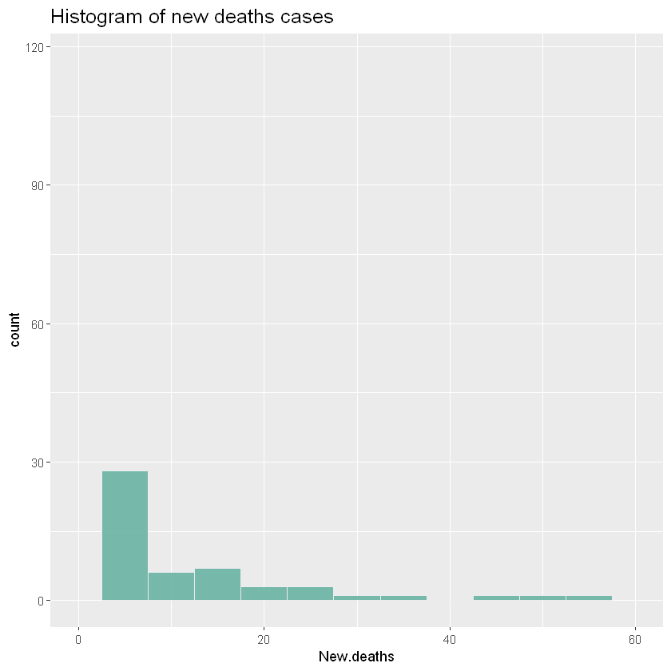

```r
ggplot(df, aes(x=New.deaths)) +
    geom_histogram( binwidth=5, fill="#69b3a2", color="#e9ecef", alpha=0.9, position = 'identity') +
    ggtitle("Histogram of new deaths cases") +
    theme(plot.title = element_text(size=15)) +
    xlim(0,60)
```

```r
png(filename = "img/New_deaths_conditional_boxplot.png", units="in", width=5, height=5, res=300)

ggplot(df, aes(x=as.factor(WHO.Region), y=New.deaths)) +
    geom_boxplot(fill="slateblue", alpha=0.2) +
    ggtitle("Boxplots of new deaths cases divided by WHO region") +
    theme(
        axis.text=element_text(size=6.5),
        axis.title=element_text(size=14,face="bold")
    ) +
    coord_cartesian(ylim = c(0, 60)) +
    xlab("WHO.Region")

dev.off()

png(filename = "img/New_deaths_boxplot.png", units="in", width=5, height=5, res=300)

ggplot(df, aes(y=New.deaths)) +
    geom_boxplot(fill="slateblue", alpha=0.2) +
    ggtitle("Boxplot of new deaths cases") +
    theme(
        axis.text=element_text(size=6.5),
        axis.title=element_text(size=14, face="bold")
    ) +
    coord_cartesian(ylim = c(0, 60))

dev.off()

png(filename = "img/New_deaths_histogram.png", units="in", width=5, height=5, res=300)

ggplot(df, aes(New.deaths)) +
    geom_histogram( binwidth=5, fill="#69b3a2", color="#e9ecef", alpha=0.9) +
    ggtitle("Histogram of new deaths cases") +
    theme(plot.title = element_text(size=15)) +
    xlim(0,60)

dev.off()
```

**png:** 2

**png:** 2

**png:** 2

#### New recovered

```r
boxplot.stats(df$New.recovered)
```

**$stats**

1. 0

2. 0

3. 24

4. 230

5. 569

**$n**

182

**$conf**

1. -2.93700016746442

2. 50.9370001674644

**$out**

1. 749

2. 2057

3. 1801

4. 33728

5. 1859

6. 11494

7. 1601

8. 1007

9. 843

10. 33598

11. 1518

12. 1931

13. 1927

14. 1833

15. 684

16. 817

17. 681

18. 8588

19. 626

20. 829

21. 1729

22. 3592

23. 955

24. 4697

25. 3077

26. 2613

27. 9848

28. 982

29. 27941

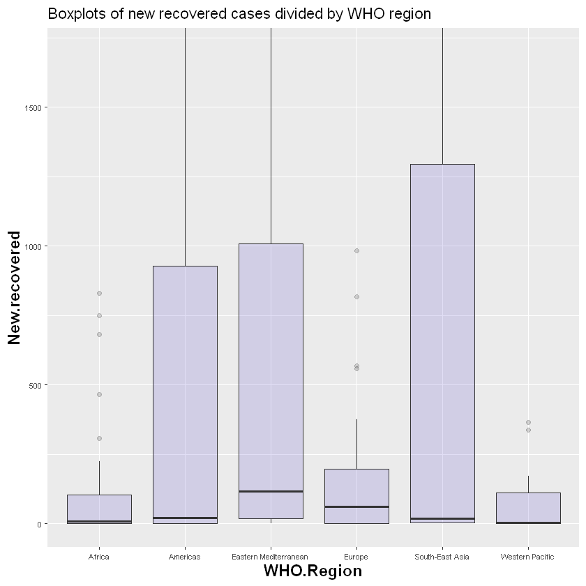

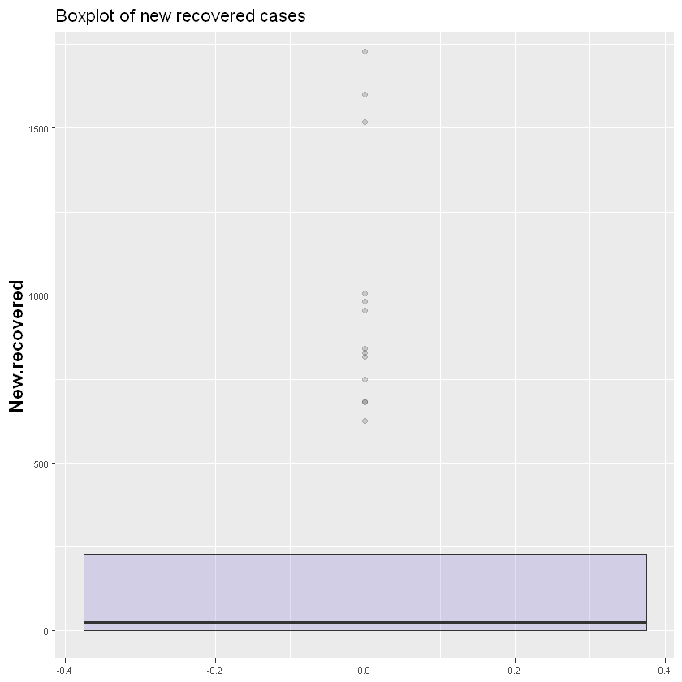

```r
ggplot(df, aes(x=as.factor(WHO.Region), y=New.recovered)) +
    geom_boxplot(fill="slateblue", alpha=0.2) +
    ggtitle("Boxplots of new recovered cases divided by WHO region") +
    theme(
        axis.text=element_text(size=6.5),
        axis.title=element_text(size=14, face="bold")
    ) +
    coord_cartesian(ylim = c(0, 1700)) +
    xlab("WHO.Region")

ggplot(df, aes(y=New.recovered)) +
    geom_boxplot(fill="slateblue", alpha=0.2) +
    ggtitle("Boxplot of new recovered cases") +
    theme(
        axis.text=element_text(size=6.5),
        axis.title=element_text(size=14, face="bold")
    ) +
    coord_cartesian(ylim = c(0, 1700))
```

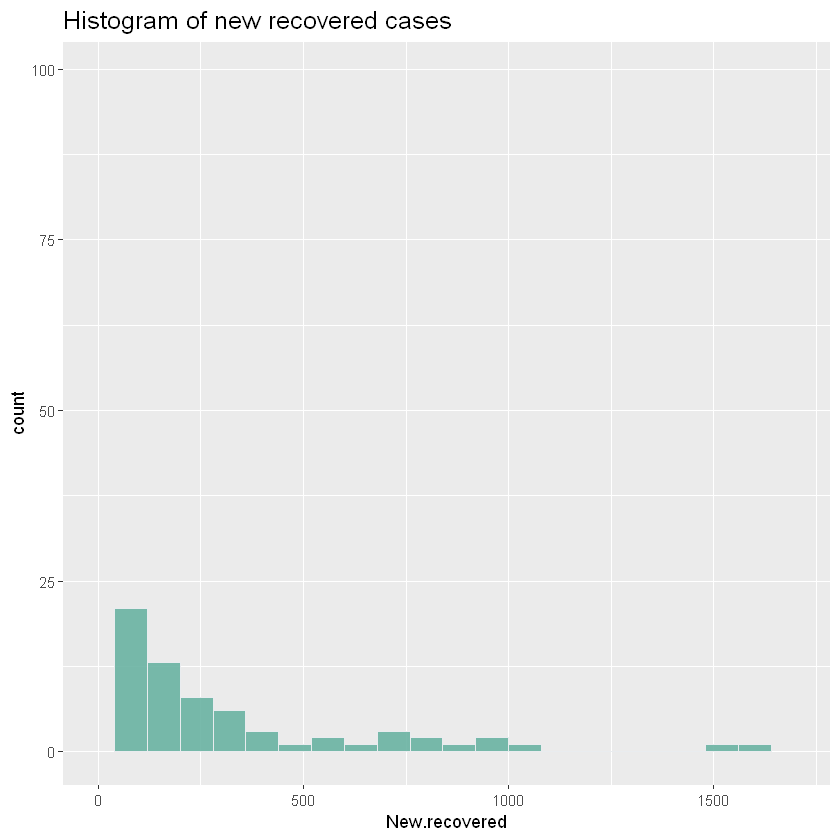

```r
ggplot(df, aes(x=New.recovered)) +
    geom_histogram( binwidth=80, fill="#69b3a2", color="#e9ecef", alpha=0.9, position = 'identity') +
    ggtitle("Histogram of new recovered cases") +
    theme(plot.title = element_text(size=15)) +
    xlim(0,1700)
```

```r
png(filename = "img/New_recovered_conditional_boxplot.png", units="in", width=5, height=5, res=300)

ggplot(df, aes(x=as.factor(WHO.Region), y=New.recovered)) +
    geom_boxplot(fill="slateblue", alpha=0.2) +
    ggtitle("Boxplots of new recovered cases divided by WHO region") +
    theme(
        axis.text=element_text(size=6.5),
        axis.title=element_text(size=14,face="bold")
    ) +
    coord_cartesian(ylim = c(0, 1700)) +
    xlab("WHO.Region")

dev.off()

png(filename = "img/New_recovered_boxplot.png", units="in", width=5, height=5, res=300)

ggplot(df, aes(y=New.recovered)) +
    geom_boxplot(fill="slateblue", alpha=0.2) +
    ggtitle("Boxplot of new recovered cases") +
    theme(
        axis.text=element_text(size=6.5),
        axis.title=element_text(size=14, face="bold")
    ) +
    coord_cartesian(ylim = c(0, 1700))

dev.off()

png(filename = "img/New_recovered_histogram.png", units="in", width=5, height=5, res=300)

ggplot(df, aes(New.recovered)) +
    geom_histogram( binwidth=80, fill="#69b3a2", color="#e9ecef", alpha=0.9) +
    ggtitle("Histogram of new recovered cases") +
    theme(plot.title = element_text(size=15)) +
    xlim(0,1700)

dev.off()
```

**png:** 2

**png:** 2

**png:** 2

#### Deaths / 100 Cases

```r
boxplot.stats(df$Deaths...100.Cases)
```

**$stats**

1. 0

2. 0.94

3. 2.13

4. 3.72

5. 6.82

**$n**

182

**$conf**

1. 1.80441365014978

2. 2.45558634985022

**$out**

1. 14.79

2. 8.13

3. 13.71

4. 13.4

5. 14.26

6. 11.13

7. 11.53

8. 10.44

9. 15.19

10. 10

11. 28.56

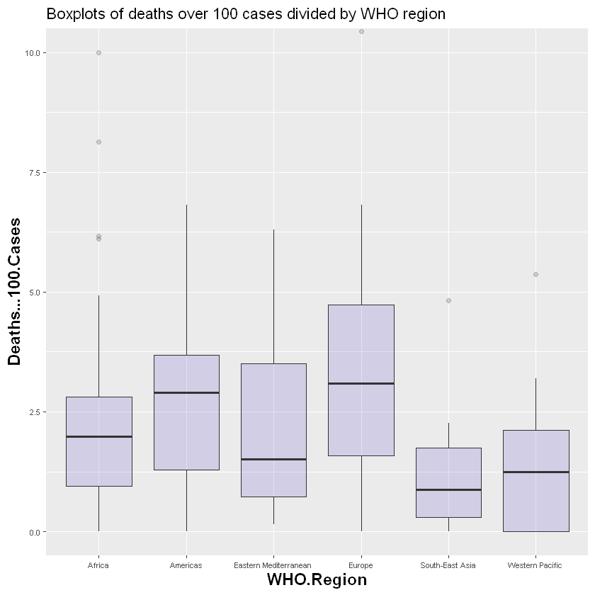

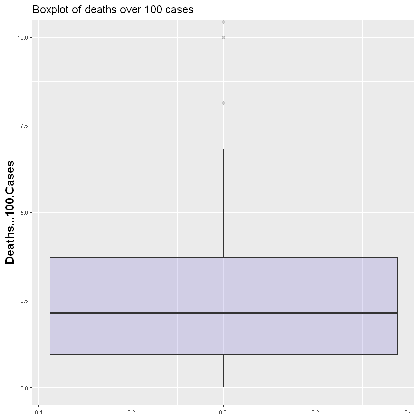

```r
ggplot(df, aes(x=as.factor(WHO.Region), y=Deaths...100.Cases)) +
    geom_boxplot(fill="slateblue", alpha=0.2) +
    ggtitle("Boxplots of deaths over 100 cases divided by WHO region") +
    theme(
        axis.text=element_text(size=6.5),
        axis.title=element_text(size=14, face="bold")
    ) +
    coord_cartesian(ylim = c(0, 10)) +
    xlab("WHO.Region")

ggplot(df, aes(y=Deaths...100.Cases)) +
    geom_boxplot(fill="slateblue", alpha=0.2) +
    ggtitle("Boxplot of deaths over 100 cases") +
    theme(
        axis.text=element_text(size=6.5),
        axis.title=element_text(size=14, face="bold")
    ) +
    coord_cartesian(ylim = c(0, 10))
```

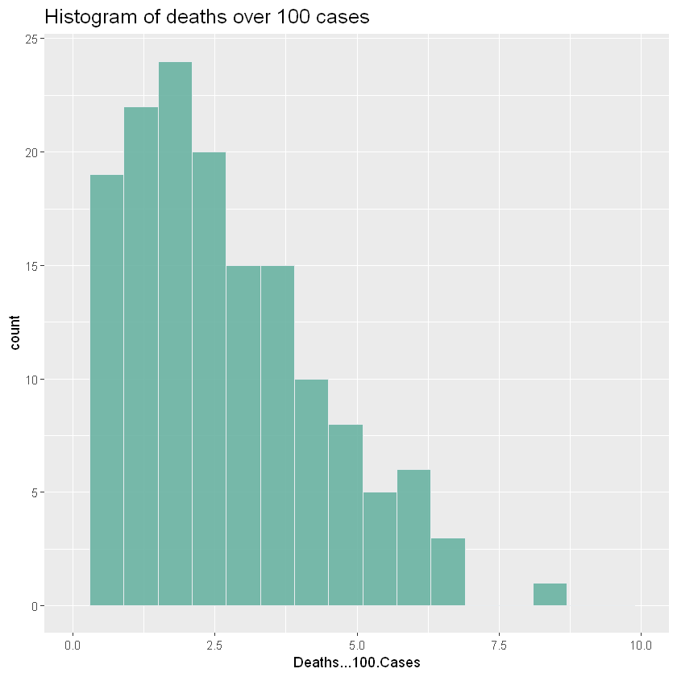

```r
ggplot(df, aes(x=Deaths...100.Cases)) +
    geom_histogram( binwidth=0.6, fill="#69b3a2", color="#e9ecef", alpha=0.9, position = 'identity') +
    ggtitle("Histogram of deaths over 100 cases") +
    theme(plot.title = element_text(size=15)) +
    xlim(0,10)
```

```r
png(filename = "img/Deaths_over_100_cases_conditional_boxplot.png", units="in", width=5, height=5, res=300)

ggplot(df, aes(x=as.factor(WHO.Region), y=Deaths...100.Cases)) +
    geom_boxplot(fill="slateblue", alpha=0.2) +
    ggtitle("Boxplots of deaths over 100 cases divided by WHO region") +
    theme(
        axis.text=element_text(size=6.5),
        axis.title=element_text(size=14,face="bold")
    ) +
    coord_cartesian(ylim = c(0, 10)) +
    xlab("WHO.Region")

dev.off()

png(filename = "img/Deaths_over_100_cases_boxplot.png", units="in", width=5, height=5, res=300)

ggplot(df, aes(y=Deaths...100.Cases)) +
    geom_boxplot(fill="slateblue", alpha=0.2) +
    ggtitle("Boxplot of deaths over 100 cases") +
    theme(
        axis.text=element_text(size=6.5),
        axis.title=element_text(size=14, face="bold")
    ) +
    coord_cartesian(ylim = c(0, 10))

dev.off()

png(filename = "img/Deaths_over_100_cases_histogram.png", units="in", width=5, height=5, res=300)

ggplot(df, aes(Deaths...100.Cases)) +
    geom_histogram( binwidth=0.6, fill="#69b3a2", color="#e9ecef", alpha=0.9) +
    ggtitle("Histogram of deaths over 100 cases") +
    theme(plot.title = element_text(size=15)) +
    xlim(0,10)

dev.off()
```

**png:** 2

**png:** 2

**png:** 2

#### Recovered / 100 Cases

```r
boxplot.stats(df$Recovered...100.Cases)
```

**$stats**

1. 0

2. 51.73

3. 72.27

4. 87.41

5. 100

**$n**

182

**$conf**

1. 68.091251452282

2. 76.448748547718

**$out**

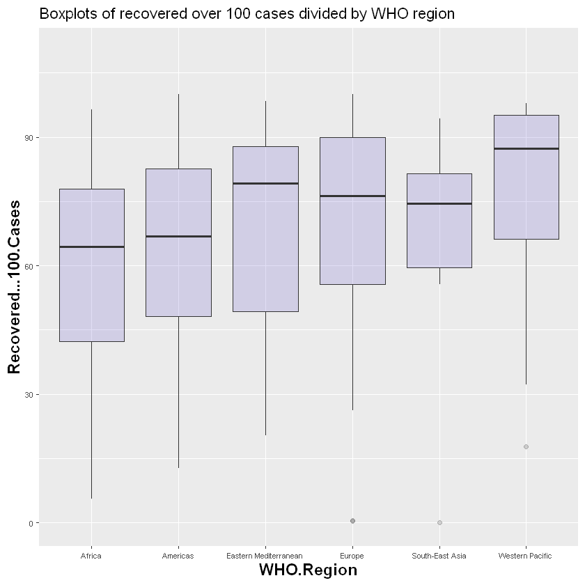

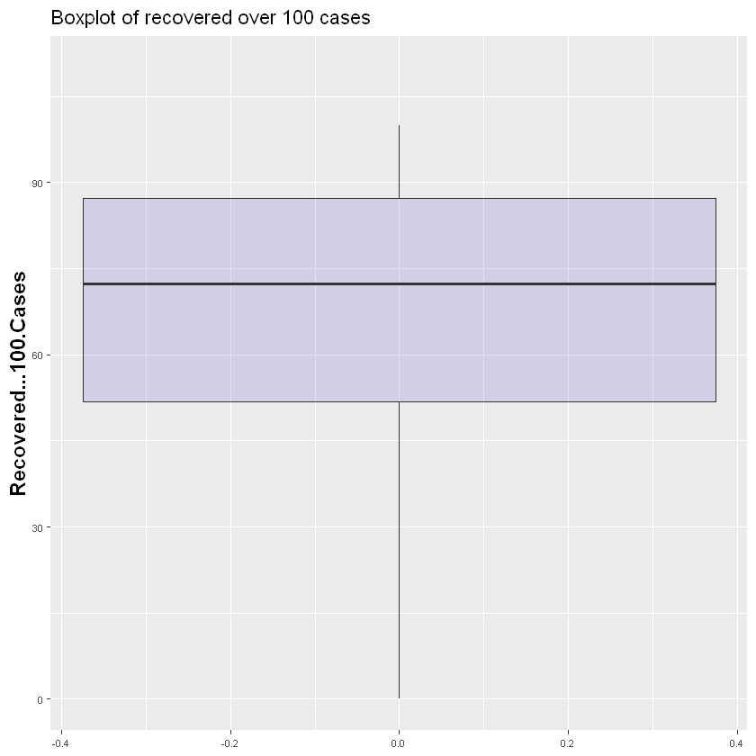

```r
ggplot(df, aes(x=as.factor(WHO.Region), y=Recovered...100.Cases)) +
    geom_boxplot(fill="slateblue", alpha=0.2) +
    ggtitle("Boxplots of recovered over 100 cases divided by WHO region") +
    theme(
        axis.text=element_text(size=6.5),
        axis.title=element_text(size=14, face="bold")
    ) +
    coord_cartesian(ylim = c(0, 110)) +
    xlab("WHO.Region")

ggplot(df, aes(y=Recovered...100.Cases)) +
    geom_boxplot(fill="slateblue", alpha=0.2) +
    ggtitle("Boxplot of recovered over 100 cases") +
    theme(
        axis.text=element_text(size=6.5),
        axis.title=element_text(size=14, face="bold")
    ) +
    coord_cartesian(ylim = c(0, 110))
```

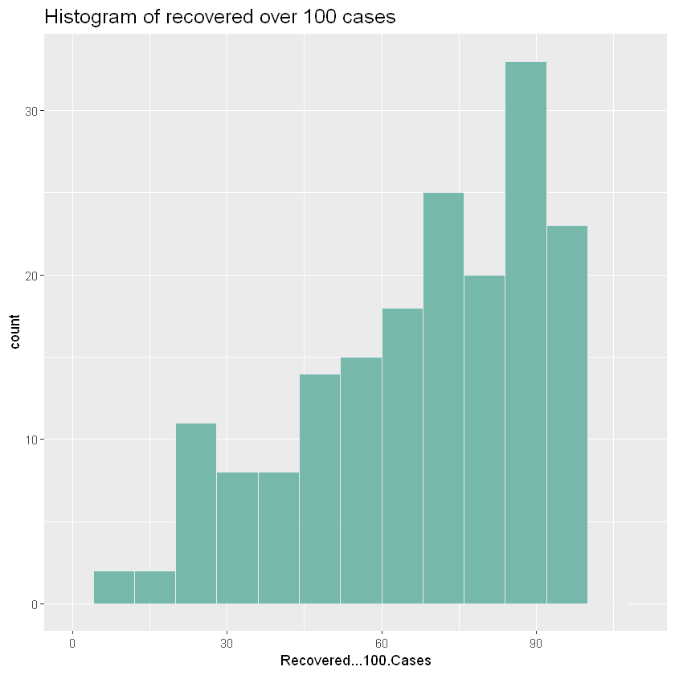

```r
ggplot(df, aes(x=Recovered...100.Cases)) +
    geom_histogram( binwidth=8, fill="#69b3a2", color="#e9ecef", alpha=0.9, position = 'identity') +
    ggtitle("Histogram of recovered over 100 cases") +
    theme(plot.title = element_text(size=15)) +
    xlim(0,110)
```

```r
png(filename = "img/Recovered_over_100_cases_conditional_boxplot.png", units="in", width=5, height=5, res=300)

ggplot(df, aes(x=as.factor(WHO.Region), y=Recovered...100.Cases)) +
    geom_boxplot(fill="slateblue", alpha=0.2) +
    ggtitle("Boxplots of recovered over 100 cases divided by WHO region") +
    theme(
        axis.text=element_text(size=6.5),
        axis.title=element_text(size=14,face="bold")
    ) +
    coord_cartesian(ylim = c(0, 110)) +
    xlab("WHO.Region")

dev.off()

png(filename = "img/Recovered_over_100_cases_boxplot.png", units="in", width=5, height=5, res=300)

ggplot(df, aes(y=Confirmed)) +
    geom_boxplot(fill="slateblue", alpha=0.2) +
    ggtitle("Boxplot of recovered over 100 cases") +
    theme(
        axis.text=element_text(size=6.5),
        axis.title=element_text(size=14, face="bold")
    ) +
    coord_cartesian(ylim = c(0, 110))

dev.off()

png(filename = "img/Recovered_over_100_cases_histogram.png", units="in", width=5, height=5, res=300)

ggplot(df, aes(Recovered...100.Cases)) +
    geom_histogram( binwidth=8, fill="#69b3a2", color="#e9ecef", alpha=0.9) +
    ggtitle("Histogram of recovered over 100 cases") +
    theme(plot.title = element_text(size=15)) +
    xlim(0,110)

dev.off()
```

**png:** 2

**png:** 2

**png:** 2